# Portfolio 1

```python
import pandas as pd
from matplotlib import pyplot as plt
from datetime import timedelta
plt.style.use('seaborn')
%matplotlib inline
```

# Analysis of Cycling Data

## Loading Data

The first dataset is an export of my ride data from [Strava](https://strava.com/), an online social network site for cycling and other sports. This data is a log of every ride since the start of 2018 and contains summary data like the distance and average speed. It was exported using the script `stravaget.py` which uses the stravalib module to read data. Some details of the fields exported by that script can be seen in [the documentation for stravalib](https://pythonhosted.org/stravalib/api.html#stravalib.model.Activity).

The exported data is a CSV file so that's easy to read, however the date information in the file is recorded in a different timezone (UTC) so we need to do a bit of conversion. In reading the data I'm setting the index of the data frame to be the datetime of the ride.

```python
strava = pd.read_csv('data/strava_export.csv', index_col='date', parse_dates=True)
strava.index = strava.index.tz_convert('UTC')
strava.head()
```

| date | average_heartrate | average_temp | average_watts | device_watts | distance | elapsed_time | elevation_gain | kudos | moving_time | workout_type |
| --- | --- | --- | --- | --- | --- | --- | --- | --- | --- | --- |
| 2018-01-02 20:47:51+00:00 | 100.6 | 21.0 | 73.8 | False | 15.2 | 94 | 316.00 m | 10 | 73 | Ride |
| 2018-01-04 01:36:53+00:00 | NaN | 24.0 | 131.7 | False | 18.0 | 52 | 236.00 m | 5 | 46 | Ride |
| 2018-01-04 02:56:00+00:00 | 83.1 | 25.0 | 13.8 | False | 0.0 | 3 | 0.00 m | 2 | 2 | Ride |
| 2018-01-04 05:37:04+00:00 | 110.1 | 24.0 | 113.6 | False | 22.9 | 77 | 246.00 m | 8 | 64 | Ride |
| 2018-01-05 19:22:46+00:00 | 110.9 | 20.0 | 147.7 | True | 58.4 | 189 | 676.00 m | 12 | 144 | Ride |

The second dataset comes from an application called [GoldenCheetah](https://www.goldencheetah.org/) which provides some analytics services over ride data. This has some of the same fields but adds a lot of analysis of the power, speed and heart rate data in each ride. This data overlaps with the Strava data but doesn't include all of the same rides.

Again we create an index using the datetime for each ride, this time combining two columns in the data (date and time) and localising to Sydney so that the times match those for the Strava data.

```python
cheetah = pd.read_csv('data/cheetah.csv', skipinitialspace=True)
cheetah.index = pd.to_datetime(cheetah['date'] + ' ' + cheetah['time'])
cheetah.index = cheetah.index.tz_localize('Australia/Sydney')
cheetah.head()
```

|  | date | time | filename | axPower | aPower Relative Intensity | aBikeScore | Skiba aVI | aPower Response Index | aIsoPower | aIF | ... | Rest AVNN | Rest SDNN | Rest rMSSD | Rest PNN50 | Rest LF | Rest HF | HRV Recovery Points | NP | IF | TSS |
| --- | --- | --- | --- | --- | --- | --- | --- | --- | --- | --- | --- | --- | --- | --- | --- | --- | --- | --- | --- | --- | --- |
| 2018-01-28 06:39:49+11:00 | 01/28/18 | 06:39:49 | 2018_01_28_06_39_49.json | 202.211 | 0.75452 | 16.6520 | 1.31920 | 1.67755 | 223.621 | 0.83441 | ... | 0 | 0 | 0 | 0 | 0 | 0 | 0 | 222.856 | 0.83155 | 20.2257 |
| 2018-01-28 07:01:32+11:00 | 01/28/18 | 07:01:32 | 2018_01_28_07_01_32.json | 226.039 | 0.84343 | 80.2669 | 1.21137 | 1.54250 | 246.185 | 0.91860 | ... | 0 | 0 | 0 | 0 | 0 | 0 | 0 | 245.365 | 0.91554 | 94.5787 |
| 2018-02-01 08:13:34+11:00 | 02/01/18 | 08:13:34 | 2018_02_01_08_13_34.json | 0.000 | 0.00000 | 0.0000 | 0.00000 | 0.00000 | 0.000 | 0.00000 | ... | 0 | 0 | 0 | 0 | 0 | 0 | 0 | 0.000 | 0.00000 | 0.0000 |
| 2018-02-06 08:06:42+11:00 | 02/06/18 | 08:06:42 | 2018_02_06_08_06_42.json | 221.672 | 0.82714 | 78.8866 | 1.35775 | 1.86002 | 254.409 | 0.94929 | ... | 0 | 0 | 0 | 0 | 0 | 0 | 0 | 253.702 | 0.94665 | 98.3269 |
| 2018-02-07 17:59:05+11:00 | 02/07/18 | 17:59:05 | 2018_02_07_17_59_05.json | 218.211 | 0.81422 | 159.4590 | 1.47188 | 1.74658 | 233.780 | 0.87231 | ... | 0 | 0 | 0 | 0 | 0 | 0 | 0 | 232.644 | 0.86808 | 171.0780 |

5 rows × 362 columns

The GoldenCheetah data contains many many variables (columns) and I won't go into all of them here. Some that are of particular interest for the analysis below are:

Here are definitions of some of the more important fields in the data. Capitalised fields come from the GoldenCheetah data while lowercase_fields come from Strava. There are many cases where fields are duplicated and in this case the values should be the same, although there is room for variation as the algorithm used to calculate them could be different in each case.

- Duration - overall duration of the ride, should be same as elapsed_time
- Time Moving - time spent moving (not resting or waiting at lights), should be the same as moving_time
- Elevation Gain - metres climbed over the ride
- Average Speed - over the ride
- Average Power - average power in watts as measured by a power meter, relates to how much effort is being put in to the ride, should be the same as * average_watts' from Strava
- Nonzero Average Power - same as Average Power but excludes times when power is zero from the average
- Average Heart Rate - should be the same as average_heartrate
- Average Cadence - cadence is the rotations per minute of the pedals
- Average Temp - temperature in the environment as measured by the bike computer (should be same as average_temp)
- VAM - average ascent speed - speed up hills
- Calories (HR) - Calorie expendature as estimated from heart rate data
- 1 sec Peak Power - this and other 'Peak Power' measures give the maximum power output in the ride over this time period. Will be higher for shorter periods. High values in short periods would come from a very 'punchy' ride with sprints for example.
- 1 min Peak Hr - a similar measure relating to Heart Rate
- NP - Normalised Power, a smoothed average power measurement, generally higher than Average Power
- TSS - Training Stress Score, a measure of how hard a ride this was
- device_watts - True if the power (watts) measures were from a power meter, False if they were estimated
- distance - distance travelled in Km
- kudos - likes from other Strava users (social network)
- workout_type - one of 'Race', 'Workout' or 'Ride'

Some of the GoldenCheetah parameters are defined [in thier documentation](https://github.com/GoldenCheetah/GoldenCheetah/wiki/UG_Glossary).

## Your Tasks

Your first task is to combine these two data frames using the [`join` method of Pandas](https://pandas.pydata.org/pandas-docs/stable/user_guide/merging.html#joining-on-index). The goal is to keep only those rows of data that appear in **both** data frames so that we have complete data for every row.

```python
result = cheetah.join(strava, how='inner')
result.head()
```

|  | date | time | filename | axPower | aPower Relative Intensity | aBikeScore | Skiba aVI | aPower Response Index | aIsoPower | aIF | ... | average_heartrate | average_temp | average_watts | device_watts | distance | elapsed_time | elevation_gain | kudos | moving_time | workout_type |
| --- | --- | --- | --- | --- | --- | --- | --- | --- | --- | --- | --- | --- | --- | --- | --- | --- | --- | --- | --- | --- | --- |
| 2018-01-27 19:39:49+00:00 | 01/28/18 | 06:39:49 | 2018_01_28_06_39_49.json | 202.211 | 0.75452 | 16.6520 | 1.31920 | 1.67755 | 223.621 | 0.83441 | ... | 120.6 | 21.0 | 153.4 | True | 7.6 | 17 | 95.00 m | 4 | 17 | Ride |
| 2018-01-27 20:01:32+00:00 | 01/28/18 | 07:01:32 | 2018_01_28_07_01_32.json | 226.039 | 0.84343 | 80.2669 | 1.21137 | 1.54250 | 246.185 | 0.91860 | ... | 146.9 | 22.0 | 187.7 | True | 38.6 | 67 | 449.00 m | 19 | 67 | Race |
| 2018-01-31 21:13:34+00:00 | 02/01/18 | 08:13:34 | 2018_02_01_08_13_34.json | 0.000 | 0.00000 | 0.0000 | 0.00000 | 0.00000 | 0.000 | 0.00000 | ... | 109.8 | 19.0 | 143.0 | False | 26.3 | 649 | 612.00 m | 6 | 113 | Ride |
| 2018-02-05 21:06:42+00:00 | 02/06/18 | 08:06:42 | 2018_02_06_08_06_42.json | 221.672 | 0.82714 | 78.8866 | 1.35775 | 1.86002 | 254.409 | 0.94929 | ... | 119.3 | 19.0 | 165.9 | True | 24.3 | 69 | 439.00 m | 6 | 65 | Ride |
| 2018-02-07 06:59:05+00:00 | 02/07/18 | 17:59:05 | 2018_02_07_17_59_05.json | 218.211 | 0.81422 | 159.4590 | 1.47188 | 1.74658 | 233.780 | 0.87231 | ... | 124.8 | 20.0 | 151.0 | True | 47.1 | 144 | 890.00 m | 10 | 134 | Ride |

5 rows × 372 columns

## Required Analysis

1. Remove rides with no measured power (where device_watts is False) - these are commutes or MTB rides
- Look at the distributions of some key variables: time, distance, average speed, average power, TSS. Are they normally distributed? Skewed?
- Explore the relationships between the following variables. Are any of them corrolated with each other (do they vary together in a predictable way)? Can you explain any relationships you observe?
  - Distance
  - Moving Time
  - Average Speed
  - Heart Rate
  - Power (watts)
  - Normalised power (NP)
  - Training Stress Score
  - Elevation Gain
- We want to explore the differences between the three categories: `Race`, `Workout` and `Ride`.
  - Use scatter plots with different colours for each category to explore how these categories differ.
  - Use histograms or box plots to visualise the different distributions of a variable for the three categories.
  - In both cases, experiment with different variables but only include those that are interesting in your final notebook (if none are interesting, show us a representative example).

## Challenge

- What leads to more `kudos`? Is there anything to indicate which rides are more popular? Explore the relationship between the main variables and kudos. Show a plot and comment on any relationship you observe.
- Generate a plot that summarises the number of km ridden each month over the period of the data. Overlay this with the *sum* of the Training Stress Score and the *average* of the Average Speed to generate an overall summary of activity.
- Generate a similar graph but one that shows the activity over a given month, with the sum of the values for each day of the month shown. So, if there are two rides on a given day, the graph should show the sum of the distances etc for these rides.

Hint: to generate these summary plots you need to use the [timeseries/date functionality](https://pandas.pydata.org/pandas-docs/stable/user_guide/timeseries.html) in Pandas to generate a new data frame containing the required data.

```python
df = result[result.device_watts == True]
df.head()
```

|  | date | time | filename | axPower | aPower Relative Intensity | aBikeScore | Skiba aVI | aPower Response Index | aIsoPower | aIF | ... | average_heartrate | average_temp | average_watts | device_watts | distance | elapsed_time | elevation_gain | kudos | moving_time | workout_type |
| --- | --- | --- | --- | --- | --- | --- | --- | --- | --- | --- | --- | --- | --- | --- | --- | --- | --- | --- | --- | --- | --- |
| 2018-01-27 19:39:49+00:00 | 01/28/18 | 06:39:49 | 2018_01_28_06_39_49.json | 202.211 | 0.75452 | 16.6520 | 1.31920 | 1.67755 | 223.621 | 0.83441 | ... | 120.6 | 21.0 | 153.4 | True | 7.6 | 17 | 95.00 m | 4 | 17 | Ride |
| 2018-01-27 20:01:32+00:00 | 01/28/18 | 07:01:32 | 2018_01_28_07_01_32.json | 226.039 | 0.84343 | 80.2669 | 1.21137 | 1.54250 | 246.185 | 0.91860 | ... | 146.9 | 22.0 | 187.7 | True | 38.6 | 67 | 449.00 m | 19 | 67 | Race |
| 2018-02-05 21:06:42+00:00 | 02/06/18 | 08:06:42 | 2018_02_06_08_06_42.json | 221.672 | 0.82714 | 78.8866 | 1.35775 | 1.86002 | 254.409 | 0.94929 | ... | 119.3 | 19.0 | 165.9 | True | 24.3 | 69 | 439.00 m | 6 | 65 | Ride |
| 2018-02-07 06:59:05+00:00 | 02/07/18 | 17:59:05 | 2018_02_07_17_59_05.json | 218.211 | 0.81422 | 159.4590 | 1.47188 | 1.74658 | 233.780 | 0.87231 | ... | 124.8 | 20.0 | 151.0 | True | 47.1 | 144 | 890.00 m | 10 | 134 | Ride |
| 2018-02-09 19:18:03+00:00 | 02/10/18 | 06:18:03 | 2018_02_10_06_18_03.json | 189.918 | 0.70865 | 125.8670 | 1.31962 | 1.54810 | 212.977 | 0.79469 | ... | 123.0 | 20.0 | 145.9 | True | 59.8 | 193 | 656.00 m | 22 | 139 | Ride |

5 rows × 372 columns

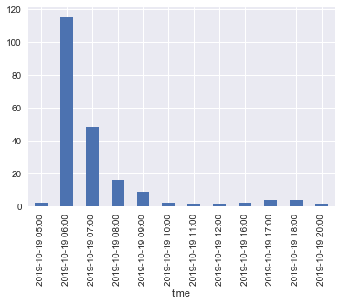

```python
time = pd.to_datetime(df['time'],errors='coerce')
time_df = time.groupby([time.dt.to_period('H')]).count().plot(kind='bar')
```

#### It is a skewed-right diagram

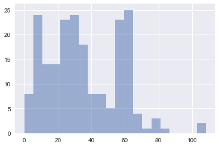

```python
distance=df['distance']
distance.hist(normed=0,histtype='stepfilled',alpha=.5,bins=20)
```

#### It is not normally distributed or skewed.

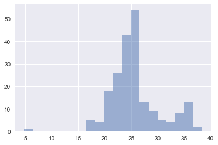

```python
average_speed=df['Average Speed']
average_speed.hist(normed=0,histtype='stepfilled',alpha=.5,bins=20)
```

#### This histogram is close to normal distribution

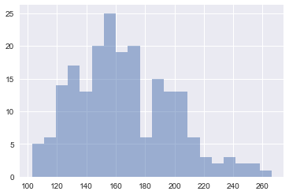

```python
average_power=df['Average Power']
average_power.hist(normed=0,histtype='stepfilled',alpha=.5,bins=20)
```

#### It should be a normal distribution diagram

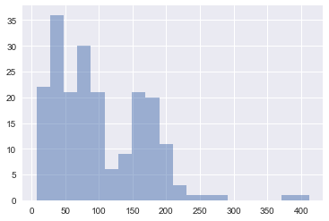

```python
TSS=df['TSS']
TSS.hist(normed=0,histtype='stepfilled',alpha=.5,bins=20)
```

#### It is close to a skewed-right diagram

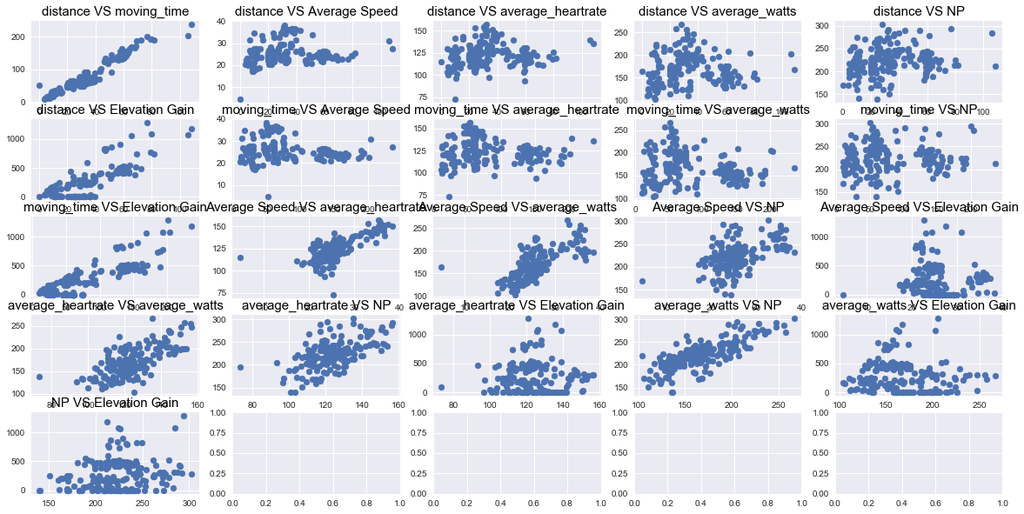

```python
features = ["distance", "moving_time", "Average Speed", "average_heartrate", "average_watts", "NP",
             "Elevation Gain"]
    #"Training Stress Score",

scatters = plt.subplots(5,5, figsize = (20, 10))[1].ravel()

pointer = 0
for i in range(len(features)-1):
    for j in range(i+1, len(features)):
        scatters[pointer].scatter(x=features[i], y=features[j], data = df)
        scatters[pointer].set_title(str(features[i])+ " VS "+ str(features[j]), fontsize = 15, color = 'black')
        pointer += 1
```

[output not shown]

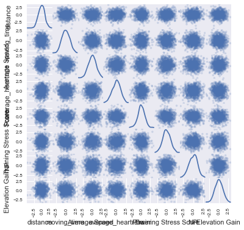

```python
from pandas.plotting import scatter_matrix
import numpy as np
df = pd.DataFrame(np.random.randn(1000,8), columns=['distance', 'moving_time','Average Speed', 'average_heartrate','Power','Training Stress Score','NP','Elevation Gain'])
scatter_matrix(df, alpha=0.2, figsize=(6, 6), diagonal='kde')
```

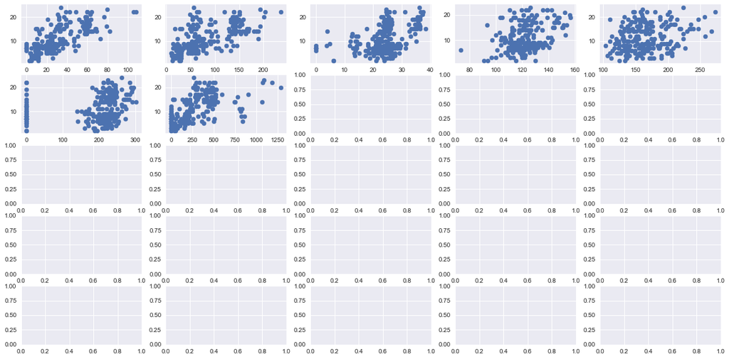

```python
Features = ["distance", "moving_time", "Average Speed", "average_heartrate", "average_watts", "NP",
             "Elevation Gain", "kudos"]
scatters = plt.subplots(5,5, figsize = (20, 10))[1].ravel()
pointer = 0
for i in range(len(Features)-1):
    scatters[pointer].scatter(x=Features[i], y=Features[7], data = result)
    pointer += 1
```

# Portfolio 2

```python
import pandas as pd
import seaborn as sns
import numpy as np
import matplotlib.pyplot as plt
from sklearn import linear_model
from sklearn.metrics import mean_squared_error, r2_score
%matplotlib inline
```

```python
energy = pd.read_csv("data/energydata_complete.csv")
```

```python
energy.head()
```

|  | date | Appliances | lights | T1 | RH_1 | T2 | RH_2 | T3 | RH_3 | T4 | ... | T9 | RH_9 | T_out | Press_mm_hg | RH_out | Windspeed | Visibility | Tdewpoint | rv1 | rv2 |
| --- | --- | --- | --- | --- | --- | --- | --- | --- | --- | --- | --- | --- | --- | --- | --- | --- | --- | --- | --- | --- | --- |
| 0 | 2016-01-11 17:00:00 | 60 | 30 | 19.89 | 47.596667 | 19.2 | 44.790000 | 19.79 | 44.730000 | 19.000000 | ... | 17.033333 | 45.53 | 6.600000 | 733.5 | 92.0 | 7.000000 | 63.000000 | 5.3 | 13.275433 | 13.275433 |
| 1 | 2016-01-11 17:10:00 | 60 | 30 | 19.89 | 46.693333 | 19.2 | 44.722500 | 19.79 | 44.790000 | 19.000000 | ... | 17.066667 | 45.56 | 6.483333 | 733.6 | 92.0 | 6.666667 | 59.166667 | 5.2 | 18.606195 | 18.606195 |
| 2 | 2016-01-11 17:20:00 | 50 | 30 | 19.89 | 46.300000 | 19.2 | 44.626667 | 19.79 | 44.933333 | 18.926667 | ... | 17.000000 | 45.50 | 6.366667 | 733.7 | 92.0 | 6.333333 | 55.333333 | 5.1 | 28.642668 | 28.642668 |
| 3 | 2016-01-11 17:30:00 | 50 | 40 | 19.89 | 46.066667 | 19.2 | 44.590000 | 19.79 | 45.000000 | 18.890000 | ... | 17.000000 | 45.40 | 6.250000 | 733.8 | 92.0 | 6.000000 | 51.500000 | 5.0 | 45.410389 | 45.410389 |
| 4 | 2016-01-11 17:40:00 | 60 | 40 | 19.89 | 46.333333 | 19.2 | 44.530000 | 19.79 | 45.000000 | 18.890000 | ... | 17.000000 | 45.40 | 6.133333 | 733.9 | 92.0 | 5.666667 | 47.666667 | 4.9 | 10.084097 | 10.084097 |

5 rows × 29 columns

```
[0, 1200, 0, 6000]
```

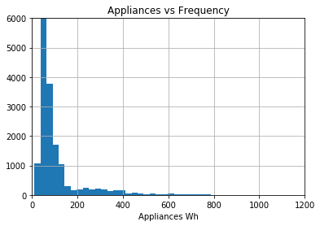

```python
energy.hist('Appliances', bins = 40)
plt.title("Appliances vs Frequency")
plt.xlabel("Appliances Wh")
plt.axis([0, 1200, 0, 6000])
```

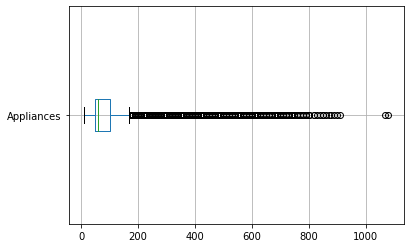

```python
energy.boxplot('Appliances', vert = 0)
```

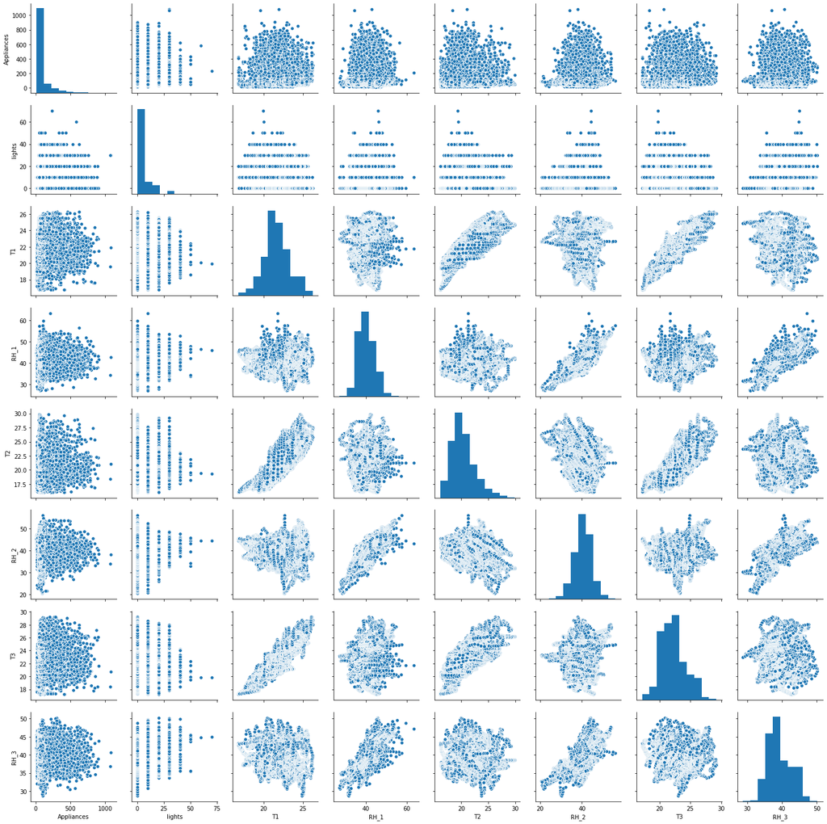

```python
table = energy[['Appliances','lights','T1','RH_1','T2','RH_2','T3','RH_3']]
sns.pairplot(table)
plt.show()
```

```python
reg = linear_model.LinearRegression()
feature_cols = ['lights','T1','RH_1','T2','RH_2','T3','RH_3']
X = energy[feature_cols]
y = energy['Appliances']
reg.fit(X,y)
print("y = x *", reg.coef_, "+", reg.intercept_)
```

```
y = x * [  2.50683818   1.17061919  19.07332393 -22.7121553  -19.47665764
  18.56108705  -0.8315593 ] + 163.459533024292
```

```python
xmin = X.min()
ymin = reg.coef_[0] * xmin + reg.intercept_
xmax = X.max()
ymax = reg.coef_[0] * xmax + reg.intercept_
```

```python
mse = ((y-reg.predict(X))**2).mean()
print(mse, np.sqrt(mse))
```

```
9235.482320981691 96.10141685210313
```

```python
predicted = reg.predict(X)
print("MSE:", mean_squared_error(y,predicted))
print("R^2:", r2_score(y,predicted))
```

```
MSE: 9235.48232098169
R^2: 0.12133574416390513
```

```python
#import training
energy_train = pd.read_csv("data/training.csv")
```

```python
feature_cols_train = ['lights','T1','RH_1','T2','RH_2','T3','RH_3']
X_train = energy_train[feature_cols_train]
y_train = energy_train['Appliances']
```

```python
#import testing
energy_test = pd.read_csv("data/testing.csv")
```

```python
feature_cols_test = ['lights','T1','RH_1','T2','RH_2','T3','RH_3']
X_test = energy_test[feature_cols_test]
y_test = energy_test['Appliances']
```

```python
#MSE and R^2 for training and testing
from sklearn import linear_model
from sklearn.metrics import mean_squared_error, r2_score
reg = linear_model.LinearRegression()
reg.fit(X_train,y_train)
predicted = reg.predict(X_test)
print("MSE:", mean_squared_error(y_test, predicted))
print("R^2:", r2_score(y_test, predicted))
```

```
MSE: 9199.869794941624
R^2: 0.10882740521117651
```

```python
from sklearn.model_selection import train_test_split

X_train, X_test, y_train, y_test = train_test_split(X, y, test_size=0.2)
print(X_train.shape, X_test.shape)
```

```
(15788, 7) (3947, 7)
```

```python
feature_cols = np.array(['lights','T1','RH_1','T2','RH_2','T3','RH_3'])
X = energy[feature_cols]
y = energy['Appliances']
X_train, X_test, y_train, y_test = train_test_split(X, y, test_size=0.2)
```

```python
from sklearn.feature_selection import RFE

estimator = linear_model.LinearRegression()
selector = RFE(estimator, 3)
selector = selector.fit(X, y)

supp = selector.get_support()
print("Selected features:", feature_cols[supp])
print("Coeffs:", selector.estimator_.coef_)
# test the model
predicted = selector.predict(X)
print("MSE:", mean_squared_error(y, predicted))
print("R^2:", r2_score(y, predicted))
```

```
Selected features: ['RH_1' 'T2' 'RH_2']
Coeffs: [ 11.56050581  -3.37838275 -10.83953795]
MSE: 9922.820158828321
R^2: 0.055942387454484765
```

# Portfolio 3 - Clustering Visualisation

K-means clustering is one of the simplest and popular unsupervised learning algorithms. Typically, unsupervised algorithms make inferences from datasets using only input vectors without referring to known, or labelled, outcomes. This notebook illustrates the process of K-means clustering by generating some random clusters of data and then showing the iterations of the algorithm as random cluster means are updated.

We first generate random data around 4 centers.

```python
import numpy as np
import pandas as pd
from matplotlib import pyplot as plt
%matplotlib inline
```

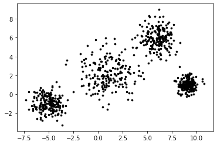

```python
center_1 = np.array([1,2])
center_2 = np.array([6,6])
center_3 = np.array([9,1])
center_4 = np.array([-5,-1])

# Generate random data and center it to the four centers each with a different variance
np.random.seed(5)
data_1 = np.random.randn(200,2) * 1.5 + center_1
data_2 = np.random.randn(200,2) * 1 + center_2
data_3 = np.random.randn(200,2) * 0.5 + center_3
data_4 = np.random.randn(200,2) * 0.8 + center_4

data = np.concatenate((data_1, data_2, data_3, data_4), axis = 0)

plt.scatter(data[:,0], data[:,1], s=7, c='k')
plt.show()
```

## 1. Generate random cluster centres

You need to generate four random centres.

This part of portfolio should contain at least:

- The number of clusters `k` is set to 4;
- Generate random centres via `centres = np.random.randn(k,c)*std + mean` where `std` and `mean` are the standard deviation and mean of the data. `c` represents the number of features in the data. Set the random seed to 6.
- Color the generated centers with `green`, `blue`, `yellow`, and `cyan`. Set the edgecolors to `red`.

```
[[ 1.0430169   5.53863665]
 [ 3.33061168 -1.4938254 ]
 [-8.35175241  6.33448312]
 [ 7.25803215 -4.15028729]]
```

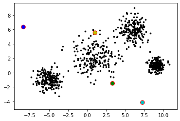

```python
np.random.seed(6)
std = np.std(data)
mean = np.mean(data)
K = 4
centres = np.random.randn(K,2)*std + mean
print(centres)

plt.scatter(data[:,0],data[:,1], s=7, c='k')
color=['y','g','b','c']
plt.scatter(centres[:,0], centres[:,1], s=70, c=color, edgecolor='r')
```

## 2. Visualise the clustering results in each iteration

You need to implement the process of k-means clustering. Implement each iteration as a seperate cell, assigning each data point to the closest centre, then updating the cluster centres based on the data, then plot the new clusters.

```python
import math


# helper function
def get_distance(p1, p2):
    distance = math.sqrt((p1[0]-p2[0])**2 + (p1[1]-p2[1])**2)
    return distance

def get_center_point(points):
    x = [p[0] for p in points]
    y = [p[1] for p in points]
    centroid = (sum(x) / len(points), sum(y) / len(points))
    return centroid

def k_means_onestep(data, centres):
    new_center = [[],[],[],[]]

    point_belone = [[] for i in range(K)]

    for p in data:
        distance = []
        distance.append(get_distance(centres[0], p))
        distance.append(get_distance(centres[1], p))
        distance.append(get_distance(centres[2], p))
        distance.append(get_distance(centres[3], p))
        idx = distance.index(min(distance))
        point_belone[idx].append(p)


    # update center point
    for c in range(len(point_belone)):
        new_center[c] = get_center_point(point_belone[c])

    return new_center, point_belone
```

```python
center_point_step1, new_data = k_means_onestep(data, centres)
# print(center_point_step1)
```

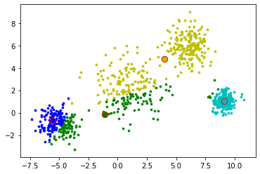

```python
for p1 in new_data[0]:
    plt.scatter(p1[0], p1[1], s=7, c=color[0])

for p2 in new_data[1]:
    plt.scatter(p2[0], p2[1], s=7, c=color[1])

for p3 in new_data[2]:
    plt.scatter(p3[0], p3[1], s=7, c=color[2])

for p4 in new_data[3]:
    plt.scatter(p4[0], p4[1], s=7, c=color[3])


plt.scatter(center_point_step1[0][0], center_point_step1[0][1], s=70, c=color[0], edgecolor='r')
plt.scatter(center_point_step1[1][0], center_point_step1[1][1], s=70, c=color[1], edgecolor='r')
plt.scatter(center_point_step1[2][0], center_point_step1[2][1], s=70, c=color[2], edgecolor='r')
plt.scatter(center_point_step1[3][0], center_point_step1[3][1], s=70, c=color[3], edgecolor='r')
```

```python
center_point_step2, new_data2 = k_means_onestep(data, center_point_step1)
# print(center_point_step2)
```

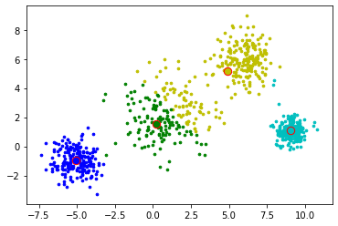

```python
for p1 in new_data2[0]:
    plt.scatter(p1[0], p1[1], s=7, c=color[0])

for p2 in new_data2[1]:
    plt.scatter(p2[0], p2[1], s=7, c=color[1])

for p3 in new_data2[2]:
    plt.scatter(p3[0], p3[1], s=7, c=color[2])

for p4 in new_data2[3]:
    plt.scatter(p4[0], p4[1], s=7, c=color[3])


plt.scatter(center_point_step2[0][0], center_point_step2[0][1], s=70, c=color[0], edgecolor='r')
plt.scatter(center_point_step2[1][0], center_point_step2[1][1], s=70, c=color[1], edgecolor='r')
plt.scatter(center_point_step2[2][0], center_point_step2[2][1], s=70, c=color[2], edgecolor='r')
plt.scatter(center_point_step2[3][0], center_point_step2[3][1], s=70, c=color[3], edgecolor='r')
```

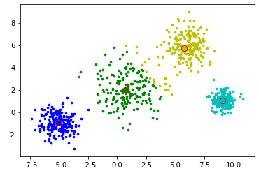

```python
center_point_step3, new_data3 = k_means_onestep(data, center_point_step2)
# print(center_point_step3)

for p1 in new_data3[0]:
    plt.scatter(p1[0], p1[1], s=7,c=color[0])

for p2 in new_data3[1]:
    plt.scatter(p2[0], p2[1], s=7,c=color[1])

for p3 in new_data3[2]:
    plt.scatter(p3[0], p3[1], s=7,c=color[2])

for p4 in new_data3[3]:
    plt.scatter(p4[0], p4[1], s=7,c=color[3])

plt.scatter(center_point_step3[0][0], center_point_step3[0][1], s=70, c=color[0], edgecolor='r')
plt.scatter(center_point_step3[1][0], center_point_step3[1][1], s=70, c=color[1], edgecolor='r')
plt.scatter(center_point_step3[2][0], center_point_step3[2][1], s=70, c=color[2], edgecolor='r')
plt.scatter(center_point_step3[3][0], center_point_step3[3][1], s=70, c=color[3], edgecolor='r')
```

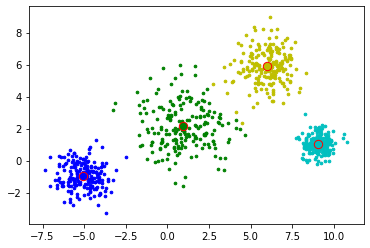

```python
center_point_step4, new_data4 = k_means_onestep(data, center_point_step3)
# print(center_point_step4)

for p1 in new_data4[0]:
    plt.scatter(p1[0], p1[1], s=7,c=color[0])

for p2 in new_data4[1]:
    plt.scatter(p2[0], p2[1], s=7, c=color[1])

for p3 in new_data4[2]:
    plt.scatter(p3[0], p3[1], s=7, c=color[2])

for p4 in new_data4[3]:
    plt.scatter(p4[0], p4[1], s=7, c=color[3])

plt.scatter(center_point_step4[0][0], center_point_step4[0][1], s=70, c=color[0], edgecolor='r')
plt.scatter(center_point_step4[1][0], center_point_step4[1][1], s=70, c=color[1], edgecolor='r')
plt.scatter(center_point_step4[2][0], center_point_step4[2][1], s=70, c=color[2], edgecolor='r')
plt.scatter(center_point_step4[3][0], center_point_step4[3][1], s=70, c=color[3], edgecolor='r')
```

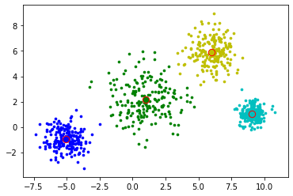

```python
center_point_step5, new_data5 = k_means_onestep(data, center_point_step4)
# print(center_point_step5)

for p1 in new_data5[0]:
    plt.scatter(p1[0], p1[1], s=7,c=color[0])

for p2 in new_data5[1]:
    plt.scatter(p2[0], p2[1], s=7,c=color[1])

for p3 in new_data5[2]:
    plt.scatter(p3[0], p3[1], s=7,c=color[2])

for p4 in new_data5[3]:
    plt.scatter(p4[0], p4[1], s=7,c=color[3])

plt.scatter(center_point_step5[0][0], center_point_step5[0][1], s=70, c=color[0], edgecolor='r')
plt.scatter(center_point_step5[1][0], center_point_step5[1][1], s=70, c=color[1], edgecolor='r')
plt.scatter(center_point_step5[2][0], center_point_step5[2][1], s=70, c=color[2], edgecolor='r')
plt.scatter(center_point_step5[3][0], center_point_step5[3][1], s=70, c=color[3], edgecolor='r')
```

```python
print(center_point_step5[0])
print(center_point_step5[1])
print(center_point_step5[2])
print(center_point_step5[3])
```

```
(6.005329800270005, 5.925288654136424)
(0.9829782540320567, 2.157879591298147)
(-5.0571701392965585, -0.9496703076782568)
(9.06363900230104, 1.0463390714865732)
```

```python
## center_1 = np.array([1,2])
## center_2 = np.array([6,6])
## center_3 = np.array([9,1])
## center_4 = np.array([-5,-1])
```

### Those centroids are quite close by comparing with initial centers. Hence, we can stop at step 5 as the last iteration.